# HW4

Group 8

11 June 2024

Group :

Lisa Bensousan - 346462534 - lisa.bensoussan@mail.huji.ac.il  
Dan Levy - 346453202 - dan.levy5@mail.huji.ac.il  
Emmanuelle Fareau - 342687233 - emmanuel.fareau@mail.huji.ac.il

### Libraries used :

```r
library(dplyr)
library(ggplot2)
library(splines)
```

### Paths and Data :

We are loading the data in our R file.

```r
load("/Users/lisabensoussan/Desktop/Lab4/chr1_line.rda")

fname= "/Users/lisabensoussan/Desktop/Lab4/reads_gc_5K.rda"
load(fname)

#load("/Users/Emmanuelle Fareau/Documents/Cours 2023-2024    (annee 4)/Maabada/chr1_line.rda")

#fname= "/Users/Emmanuelle Fareau/Downloads/reads_gc_5K.rda"

#load("")
```

## Introduction :

### Question א :

We want an overview of our data as we did in class :

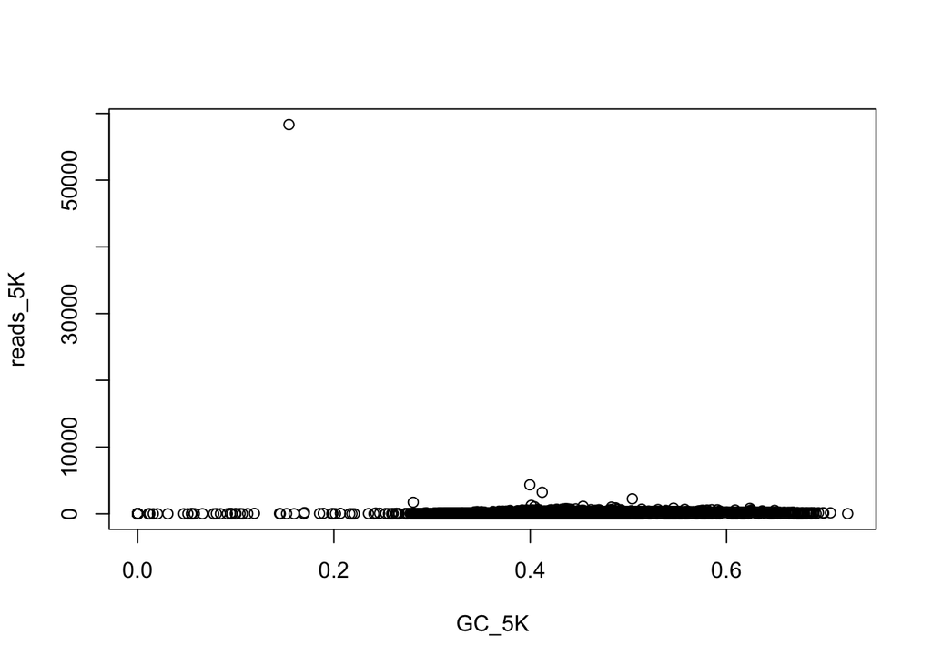

```r
if(any(GC_5K>1)){
  GC_5K = GC_5K / 5000
}

plot(GC_5K,reads_5K)
```

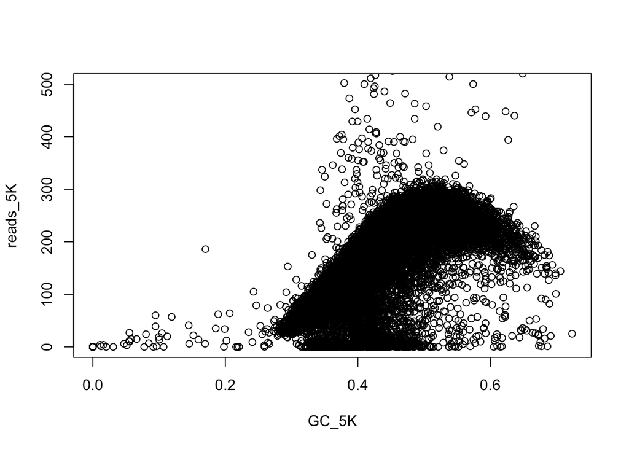

```r
plot(GC_5K,reads_5K,ylim = c(0,500))
```

In this analysis, we aimed to investigate the relationship between GC content and coverage in DNA sequence data using polynomial regression. First, we loaded the DNA sequence data and converted it into a character vector to handle individual nucleotide letters (A, C, G, T). We also prepared the coverage data `reads_5K` as a numeric vector. To align the DNA sequence data with the coverage data, we segmented the sequence into equal-sized chunks corresponding to the length of the coverage data.

```r
sequence <- chr1_line
sequence <- as.character(sequence)

reads_5K <- as.numeric(reads_5K)

segment_length <- floor(length(sequence) / length(reads_5K))
num_segments <- length(reads_5K)

segments <- split(sequence, rep(1:num_segments, each = segment_length, length.out = length(sequence)))
```

Next, we calculated the GC content for each segment, defined as the sum of ‘G’ and ‘C’ nucleotides, and created a dataframe `data` containing the GC content and the corresponding coverage values.

```r
calculate_gc_content <- function(seq) {
  gc_count <- sum(seq == "G" | seq == "C")
  return(gc_count)
}


gc_contents <- sapply(segments, calculate_gc_content)


stopifnot(length(gc_contents) == length(reads_5K))

data <- data.frame(gc_content = gc_contents, coverage = reads_5K)
data <- na.omit(data)
```

We then defined a function to remove outliers based on the residuals from a third-degree polynomial regression, filtering out data points with residuals beyond three standard deviations.

```r
remove_outliers <- function(data) {
  model <- lm(coverage ~ poly(gc_content, 3), data = data)
  residuals <- residuals(model)
  data$residuals <- residuals
  threshold <- 3 * sd(data$residuals, na.rm = TRUE)

  cleaned_data <- data %>%
    filter(abs(residuals) <= threshold)

  return(cleaned_data)
}
```

We performed polynomial regression for degrees 1, 2, and 3 to model the relationship between GC content and coverage. For each degree, we fitted the regression model, predicted the coverage values, and calculated the residuals. Finally, we generated plots to visualize the regression results, showing the observed coverage against the GC content along with the predicted coverage values.

This approach allowed us to analyze how well the polynomial models fit the data and to identify any patterns or discrepancies.

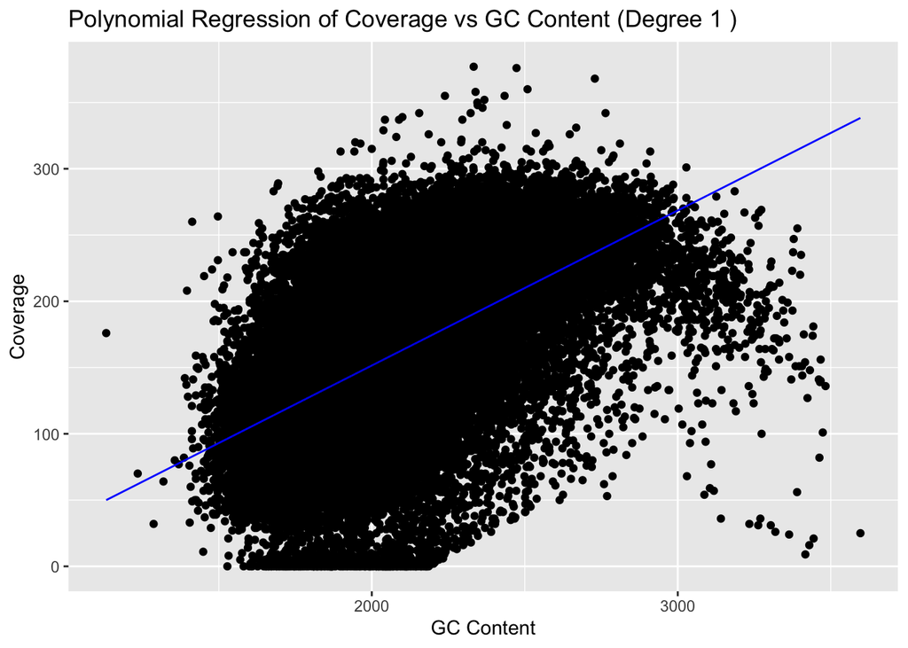

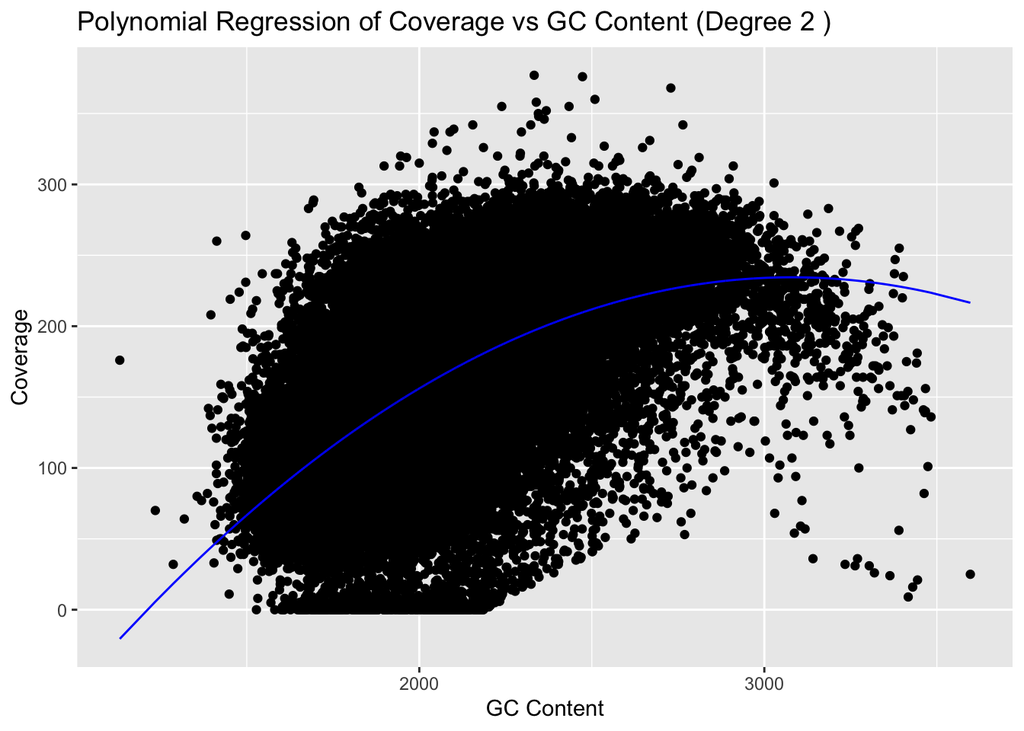

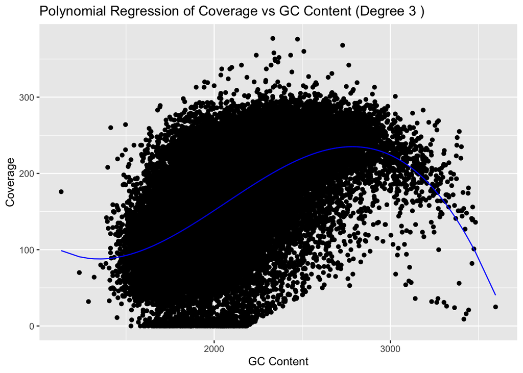

```r
perform_regression <- function(data, degree) {
  cleaned_data <- remove_outliers(data)
  model <- lm(coverage ~ poly(gc_content, degree), data = cleaned_data)
  summary(model)

  predicted_coverage <- predict(model, newdata = cleaned_data)
  residuals <- residuals(model)

  cleaned_data$predicted_coverage <- predicted_coverage
  cleaned_data$residuals <- residuals

  plot_regression <- ggplot(cleaned_data, aes(x = gc_content, y = coverage)) +
    geom_point() +
    geom_line(aes(y = predicted_coverage), color = "blue") +
    ggtitle(paste("Polynomial Regression of Coverage vs GC Content (Degree", degree, ")")) +
    xlab("GC Content") +
    ylab("Coverage")

  print(plot_regression)
}



for (degree in 1:3) {
  perform_regression(data, degree)
}
```

### Question ב :

In this analysis, we aimed to investigate the residuals from the polynomial regression models between `GC` content and `coverage` in DNA sequence data. First, we defined a function `residuals_regression` that generates a plot for the residuals of the polynomial regression model. This function takes in the data and the degree of the polynomial as inputs.

Inside the function, we used `ggplot2` to create a scatter plot of the residuals against the `GC` content.

We then looped through polynomial degrees 1, 2, and 3, calling the `residuals_regression` function for each degree.

This allowed us to visualize the residuals from the regression models of different complexities, helping us understand how the fit of the model changes with increasing polynomial degrees and to identify any systematic patterns in the residuals.

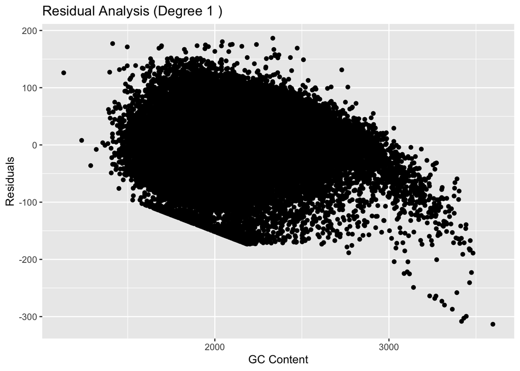

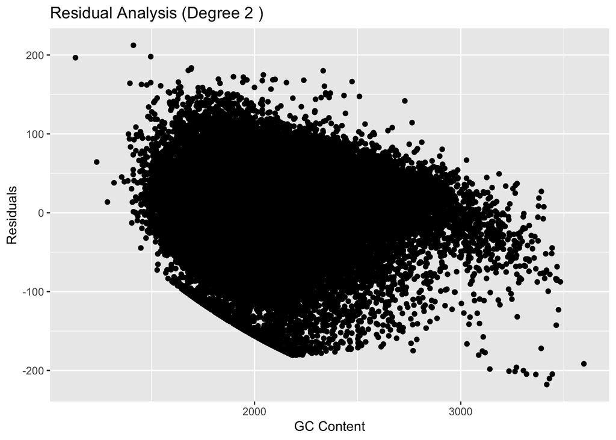

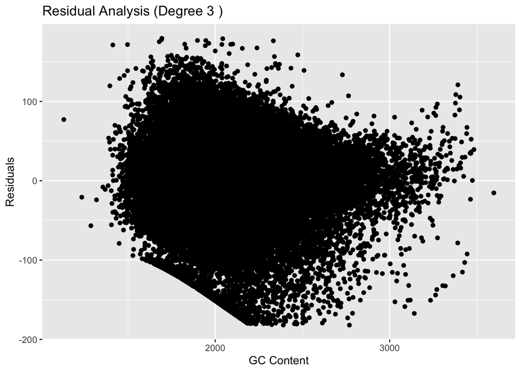

```r
# sans outliers

residuals_regression <- function(data, degree) {
  cleaned_data <- remove_outliers(data)
  model <- lm(coverage ~ poly(gc_content, degree), data = cleaned_data)
  summary(model)

  predicted_coverage <- predict(model, newdata = cleaned_data)
  residuals <- residuals(model)

  cleaned_data$predicted_coverage <- predicted_coverage
  cleaned_data$residuals <- residuals

  plot_residuals <- ggplot(cleaned_data, aes(x = gc_content, y = residuals)) +
    geom_point() +
    ggtitle(paste("Residual Analysis (Degree", degree, ")")) +
    xlab("GC Content") +
    ylab("Residuals")
  print(plot_residuals)
}

for (degree in 1:3) {
  residuals_regression(data, degree)
}
```

### Question ג :

we need to calculate the prediction quality for polynomial models of degree 1, 2 and 3 compared to a simple linear model. A common way to measure prediction quality is to use the coefficient of determination $R^2$ or the mean square error (MSE). We will compare these measurements between the different models to assess the improvement in fit.

```r
calculate_metrics <- function(model, data) {
  predicted <- predict(model, newdata = data)
  actual <- data$coverage
  ss_res <- sum((actual - predicted) ^ 2)
  ss_tot <- sum((actual - mean(actual)) ^ 2)
  r_squared <- 1 - (ss_res / ss_tot)
  mse <- mean((actual - predicted) ^ 2)
  return(list(r_squared = r_squared, mse = mse))
}


perform_regression <- function(data, degree) {
  cleaned_data <- remove_outliers(data)
  model <- lm(coverage ~ poly(gc_content, degree), data = cleaned_data)
  summary_model <- summary(model)
  print(summary_model)

  metrics <- calculate_metrics(model, cleaned_data)
  cat("\nR-squared:", metrics$r_squared, "\n")
  cat("MSE:", metrics$mse, "\n")

  predicted_coverage <- predict(model, newdata = cleaned_data)
  residuals <- residuals(model)

  cleaned_data$predicted_coverage <- predicted_coverage
  cleaned_data$residuals <- residuals

  return(metrics)
}


metrics_list <- list()


for (degree in 1:3) {
  cat("\n\n### For Degree" , degree, "###\n\n")
  metrics_list[[degree]] <- perform_regression(data, degree)
}
```

```
##
##
## ### For Degree 1 ###
##
##
## Call:
## lm(formula = coverage ~ poly(gc_content, degree), data = cleaned_data)
##
## Residuals:
##      Min       1Q   Median       3Q      Max
## -313.343  -32.789    2.485   35.397  186.525
##
## Coefficients:
##                           Estimate Std. Error t value Pr(>|t|)
## (Intercept)               161.4419     0.2453   658.2   <2e-16 ***
## poly(gc_content, degree) 7661.8547    51.7691   148.0   <2e-16 ***
## ---
## Signif. codes:  0 '***' 0.001 '**' 0.01 '*' 0.05 '.' 0.1 ' ' 1
##
## Residual standard error: 51.77 on 44546 degrees of freedom
## Multiple R-squared:  0.3296, Adjusted R-squared:  0.3296
## F-statistic: 2.19e+04 on 1 and 44546 DF,  p-value: < 2.2e-16
##
##
## R-squared: 0.3296326
## MSE: 2679.923
##
##
## ### For Degree 2 ###
##
##
## Call:
## lm(formula = coverage ~ poly(gc_content, degree), data = cleaned_data)
##
## Residuals:
##      Min       1Q   Median       3Q      Max
## -217.864  -31.154    3.106   34.382  212.291
##
## Coefficients:
##                             Estimate Std. Error t value Pr(>|t|)
```

[output cut: 26 more lines]

```
##                            Estimate Std. Error t value Pr(>|t|)
## (Intercept)                 161.442      0.239  675.37   <2e-16 ***
## poly(gc_content, degree)1  7661.855     50.453  151.86   <2e-16 ***
## poly(gc_content, degree)2 -1945.581     50.453  -38.56   <2e-16 ***
## poly(gc_content, degree)3 -1486.793     50.453  -29.47   <2e-16 ***
## ---
## Signif. codes:  0 '***' 0.001 '**' 0.01 '*' 0.05 '.' 0.1 ' ' 1
##
## Residual standard error: 50.45 on 44544 degrees of freedom
## Multiple R-squared:  0.3633, Adjusted R-squared:  0.3633
## F-statistic:  8472 on 3 and 44544 DF,  p-value: < 2.2e-16
##
##
## R-squared: 0.3633003
## MSE: 2545.33
```

```r
for (degree in 2:3) {
  cat("\n\n### Improvement from Degree 1 to Degree", degree, "###\n\n")
  improvement_r_squared <- metrics_list[[degree]]$r_squared / metrics_list[[1]]$r_squared
  improvement_mse <- metrics_list[[1]]$mse / metrics_list[[degree]]$mse
  cat("Improvement in R-squared:", improvement_r_squared, "\n")
  cat("Improvement in MSE:", improvement_mse, "\n")
}
```

```
##
##
## ### Improvement from Degree 1 to Degree 2 ###
##
## Improvement in R-squared: 1.064481
## Improvement in MSE: 1.032745
##
##
## ### Improvement from Degree 1 to Degree 3 ###
##
## Improvement in R-squared: 1.102137
## Improvement in MSE: 1.052878
```

```r
cat("\n\n### Improvement from Degree 2 to Degree 3###\n\n")
```

```
##
##
## ### Improvement from Degree 2 to Degree 3###
```

```r
improvement_r_squared <- metrics_list[[3]]$r_squared / metrics_list[[2]]$r_squared
improvement_mse <- metrics_list[[2]]$mse / metrics_list[[3]]$mse
cat("Improvement in R-squared:", improvement_r_squared, "\n")
```

```
## Improvement in R-squared: 1.035375
```

```r
cat("Improvement in MSE:", improvement_mse, "\n")
```

```
## Improvement in MSE: 1.019495
```

Degree 1 to Degree 2 - Transition from a simple linear model to a quadratic model.  
Degree 1 to Degree 3 - Transition from a linear model to a cubic model.

### Question ד :

We need to examine whether the prediction quality (measured by residuals) varies across different GC values. We can analyze this visually using plots of residuals versus GC content and numerically by comparing residuals for different ranges of GC values.

```r
perform_regression_and_return_cleaned_data <- function(data, degree) {
  cleaned_data <- remove_outliers(data)

  model <- lm(coverage ~ poly(gc_content, degree), data = cleaned_data)
  summary_model <- summary(model)
  print(summary_model)

  predicted_coverage <- predict(model, newdata = cleaned_data)
  residuals <- residuals(model)

  cleaned_data$predicted_coverage <- predicted_coverage
  cleaned_data$residuals <- residuals

  return(cleaned_data)
}


cleaned_data <- perform_regression_and_return_cleaned_data(data, 2)
```

```
##
## Call:
## lm(formula = coverage ~ poly(gc_content, degree), data = cleaned_data)
##
## Residuals:
##      Min       1Q   Median       3Q      Max
## -217.864  -31.154    3.106   34.382  212.291
##
## Coefficients:
##                             Estimate Std. Error t value Pr(>|t|)
## (Intercept)                 161.4419     0.2414  668.88   <2e-16 ***
## poly(gc_content, degree)1  7661.8547    50.9424  150.40   <2e-16 ***
## poly(gc_content, degree)2 -1945.5812    50.9424  -38.19   <2e-16 ***
## ---
## Signif. codes:  0 '***' 0.001 '**' 0.01 '*' 0.05 '.' 0.1 ' ' 1
##
## Residual standard error: 50.94 on 44545 degrees of freedom
## Multiple R-squared:  0.3509, Adjusted R-squared:  0.3509
## F-statistic: 1.204e+04 on 2 and 44545 DF,  p-value: < 2.2e-16
```

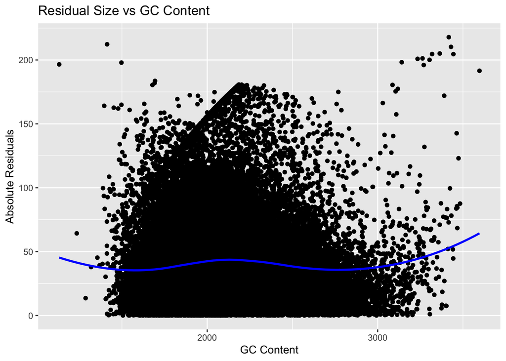

```r
cleaned_data <- as.data.frame(cleaned_data)

# Ajouter les tranches de GC au dataframe
cleaned_data$gc_bins <- cut(cleaned_data$gc_content, breaks = quantile(cleaned_data$gc_content, probs = seq(0, 1, by = 0.2)), include.lowest = TRUE)

ggplot(cleaned_data, aes(x = gc_content, y = abs(residuals))) +
  geom_point() +
  geom_smooth(method = "loess", color = "blue", se = FALSE) +
  ggtitle("Residual Size vs GC Content") +
  xlab("GC Content") +
  ylab("Absolute Residuals")
```

```r
# Comparaison numérique des résidus par tranches de GC
residual_summary <- cleaned_data %>%
  group_by(gc_bins) %>%
  summarise(mean_residual = mean(abs(residuals)), sd_residual = sd(abs(residuals)))

print(residual_summary)
```

```
## # A tibble: 5 × 3
##   gc_bins             mean_residual sd_residual
##   <fct>                       <dbl>       <dbl>
## 1 [1.13e+03,1.82e+03]          36.2        29.3
## 2 (1.82e+03,1.96e+03]          40.3        31.1
## 3 (1.96e+03,2.11e+03]          43.1        33.5
## 4 (2.11e+03,2.33e+03]          42.8        34.0
## 5 (2.33e+03,3.6e+03]           36.9        29.8
```

- **Coefficients:**
  - **Intercept:** 161.442 (Standard Error: 0.2414) - Represents the baseline coverage when GC content is at the median level.
  - **First Polynomial Term (Degree 1):** 7661.855 (Standard Error: 50.9424) - Indicates a strong positive association between coverage and GC content.
  - **Second Polynomial Term (Degree 2):** -1945.581 (Standard Error: 50.9424) - Reflects the curvature in the relationship, suggesting that the effect of GC content on coverage may increase at a decreasing rate or may have a peak.
- **Residual Standard Error:** 50.94 - Represents the typical deviation of the observed coverages from the model-predicted values, measured on the same scale as the coverage.
- **Multiple R-squared:** 0.3509 - Approximately 35.09% of the variance in coverage is explained by the model, which is substantial but indicates room for potential improvement or unexplained variability.
- **Adjusted R-squared:** Same as R-squared in this context, confirming model efficiency after adjusting for the number of predictors.

#### Residual Analysis:

The model residuals have a median close to zero, suggesting no bias in prediction, but the range of residuals (from -217.864 to 212.291) indicates potential outliers or anomalies in coverage that the model does not perfectly capture.

### Summary:

The analysis indicates that while a polynomial model of GC content significantly predicts coverage, the variability explained is not complete, suggesting complex dynamics in genomic data. The model successfully captures the general trend but also highlights the need for possibly more sophisticated models or the inclusion of other explanatory variables to better understand and predict coverage across different GC content levels.

## Short summary :

In this analysis, we investigated the distribution and behavior of genomic data across several models and tests. Our primary goal was to examine how the sequencing coverage and GC content across chromosome 1 conform to theoretical expectations and how these variables interact.

Overall, the comprehensive analysis across different statistical methods and models helped illuminate the complexities of genomic data, emphasizing areas where theoretical models align with or deviate from observed data. This synthesis not only enhances our understanding of genomic sequencing but also informs improvements in data processing and analysis strategies.